# MixSIAR tutorial

pmgh

2023/2/10

# MixSIAR 案例教程

MixSIAR，使用贝叶斯模型，依据指纹因子数据，估计物源对混合物的贡献比例，尤其是食物网中的食物来源问题。目前，MixSIAR在cran和github上的版本均为v3.1.12（2020-10-20发布）,但是github上的，多了5个函数（函数及作用见案例5）。

本教程共包括若干水土保持学案例，以及11个官方案例（其中前6个来自github的tutorials，后5个补充自官方手册，但案例顺序略有改变）。

涉及资源包括MixSIAR包以及JAGS软件：

1. CRAN: https://cran.r-project.org/web/packages/MixSIAR/index.html
2. github: https://github.com/brianstock/MixSIAR
3. JAGS: https://sourceforge.net/projects/mcmc-jags/files/JAGS/
4. RDocumentation: https://www.rdocumentation.org/packages/MixSIAR/versions/3.1.12
5. Official tutorials: http://brianstock.github.io/MixSIAR/articles/index.html
6. 官方手册：MixSIAR安装文件夹下的mixsiar_manual_small.pdf
7. Stock B C, et al. PeerJ 2018: https://peerj.com/articles/5096/

# 总述

## MixSIAR经验总结

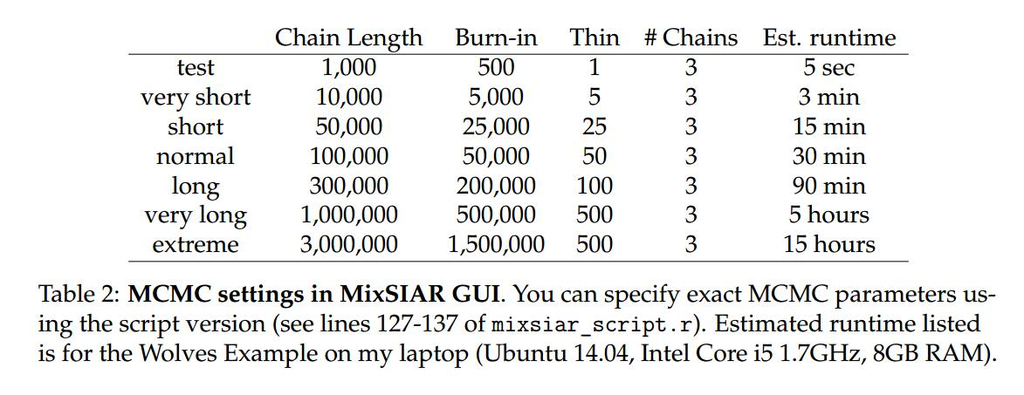

## MixSIAR基础工作流程及所需函数

1. 加载数据文件（rmarkdown以-为无序列表，以三个制表符为二级）
   - load_mix_data (加载混合物数据)
   - load_source_data (加载物源地数据)
   - load_discr_data (加载营养鉴别因子即TDF数据)
2. 数据检验（建模前）
   - plot_data (绘制二维示踪因子图)
   - calc_area (计算源凸包的归一化表面积)
   - plot_prior (绘制先验信息)
3. 选择模型结构
   - write_JAGS_model (编写JAGS模型)
4. 运行模型
   - run_model (运行JAGS模型)
5. 使用诊断器判定模型是否已收敛
   - output_JAGS (检查模型是否收敛)
6. 分析模型结果
   - output_JAGS (查看模型结果和后验密度图)

# 自编实用函数

## 函数1-将raw型源数据转为means型

```r
raw2means <- function(method = "clipboard", rawdata=NULL, fullfilename=NULL){
  # 定义一个转换函数，将raw格式的sources，转换为means格式
  # 四种方式clipboard/data/filechoose/filename：
  # 1. method="clipboard"为默认，从剪切板读取，结果写入剪切板
  # 2. method="data"为输入数据，结果输出为数据
  # 3. method="filechoose"为从路径选择raw文件，将means结果写入同路径下的csv文件
  # 4. method="filename"为输入raw的路径+文件名，将means结果写入同路径下的csv文件
  # 注意输入的raw格式，要求第一列为"sources"，其余列均为指纹因子
  # library(data.table)
  # library(magrittr)
  # 定义一个专职转换的函数
  r2m <- function(data.raw){
    fin.name <- names(data.raw)[-1]
    m.name <- paste0("Mean", fin.name)
    s.name <- paste0("SD", fin.name)
    n.name <- "n"
    m <- data.raw[, lapply(.SD, mean), by="sources"] %>% set_colnames(c("sources", m.name))
    s <- data.raw[, lapply(.SD, sd), by="sources"] %>% .[,-1] %>% set_colnames(s.name)
    n <- data.raw[, lapply(.SD, length), by="sources"] %>% .[,2] %>% set_colnames(n.name)
    data.means <- cbind(m,s,n)
    return(data.means)
  }
  # 分情况
  if(method == "clipboard"){
    # 如果是剪切板，则读取、转换、输出到剪切板
    data.raw <- read.table("clipboard", header = T) %>% setDT()
    data.means <- r2m(data.raw)
    write.table(data.means, "clipboard", row.names = F, sep = "\t")
    message("Done!")
    return(invisible())
  } else if(method == "data"){
    # 如果是数据输入，则转换、输出到R对象
    if(!is.null(rawdata)) stop("Data does not exist!")
    data.means <- r2m(data.raw)
    return(data.means)
  } else if(method == "filechoose"){
    # 如果是文件选择，先记录下文件名
    file.raw.name <- file.choose() %>% gsub("\\\\", "/", .)
  } else if(method == "filename"){
    # 如果是文件名，先记录下文件名
    if(!file.exists(fullfilename)) stop("File does not exist!")
    file.raw.name <- fullfilename %>% gsub("\\\\", "/", .)
  } else{
    # 其他情况，停止
    stop("Method error! (Try clipboard/data/filechoose/filename)")
  }
  # 先进行数据转换
  data.raw <- fread(file.raw.name)
  data.means <- r2m(data.raw)
  # 根据raw的文件名，生成储存means所需的文件名
  file.raw.dir <- dirname(file.raw.name)
  t.file.means.name <- gsub(paste0(file.raw.dir, "/"), "", file.raw.name)
  # 生成menas的文件名，如果raw文件名有区分，则直接替换为means，若没有，则追加means
  if(grepl("raw", t.file.means.name)){
    file.means.name <- gsub("raw", "means", t.file.means.name)
  } else{
    file.means.name <- gsub(".csv", "_means.csv", t.file.means.name)
  }
  # 保存means
  fwrite(data.means, paste0(file.raw.dir, "/", file.means.name))
  message("Your means-type file (the path same with raw one): ")
  message(paste0("      ", file.means.name))
  return(invisible())
}
```

## 函数2-生成值全为0的TDF

```r
load_discr_zero <- function(mix, source){
  # 读取指纹因子均值、指纹因子标准差、物源的名和数量
  s.m.name <- mix$MU_names
  s.m.number <- length(s.m.name)
  s.sig.name <- mix$SIG_names
  s.sig.number <- length(s.sig.name)
  source.name <- source$source_names
  source.number <- length(source.name)
  # 生成均值0矩阵
  s.m <- matrix(data=0, nrow = source.number, ncol = s.m.number)
  colnames(s.m) <- s.m.name
  rownames(s.m) <- source.name
  # 生成标准差0矩阵
  s.sig <- matrix(data=0, nrow = source.number, ncol = s.sig.number)
  colnames(s.sig) <- s.sig.name
  rownames(s.sig) <- source.name
  # 输出结果
  res <- list(mu = s.m, sig2 = s.sig)
  return(res)
}
```

## 函数3-狄利克雷超参数正规化

```r
# 定义一个先验信息超参数正规化函数
standard.alpha <- function(a, zero = 0.01){
  s.a <- a*length(a)/sum(a)
  s.a[which(s.a == 0)] <- zero
  return(s.a)
}
```

# 水土保持案例

## 水保1-burnedarea：人工混合物

案例说明

```r
# 1.建模准备
# 加载包
library(MixSIAR)
# 案例序号
enum <- 1
# 案例名称
enam <- "burnedarea"
# 案例路径
edir <- paste0("D:/#R/learn_Bayesian/MixSIAR_WSexample", enum, "-", enam)
# 定义文件路径
setwd(edir)

# 2.创建所需数据和模型的列表
mod.n <- 3
mix <- vector("list", mod.n)
source <- vector("list", mod.n)
discr <- vector("list", mod.n)
alpha <- vector("list", mod.n)
jags.mod <- vector("list", mod.n)

# 3.设置先验信息
# 定义一个先验信息超参数正规化函数
standard.alpha <- function(a, zero = 0.01){
  s.a <- a*length(a)/sum(a)
  s.a[which(s.a == 0)] <- zero
  return(s.a)
}
# 指定每个模型的先验信息超参数
alpha[[1]] <- alpha[[2]] <- alpha[[3]] <- 1
# alpha[[1]] <- standard.alpha(c(0.3333, 0.3333, 0.3333))
# alpha[[2]] <- standard.alpha(c(0.4, 0.2, 0.4))
# alpha[[3]] <- standard.alpha(c(0.6, 0.2, 0.2))
# alpha[[1]] <- standard.alpha(c(0.45, 0.1, 0.45))
# alpha[[2]] <- standard.alpha(c(0.1, 0.8, 0.1))
# alpha[[3]] <- standard.alpha(c(0.1, 0.45, 0.45))

# 4.构建并运行模型
startTime <- Sys.time()
for(mod in 1:mod.n){
  # 4.1加载混合物数据
  mix[[mod]] <- load_mix_data(filename = paste0(edir, "/", enam, "-mixsiar_mix_", mod, ".csv"),
                              iso_names = c("cs137","pb210","xlf"),
                              factors = NULL,
                              fac_random = NULL,
                              fac_nested = NULL,
                              cont_effects = NULL)
  # 4.2加载物源数据
  source[[mod]] <- load_source_data(filename = paste0(edir, "/", enam, "-mixsiar_source_means.csv"),
                                    source_factors = NULL,
                                    conc_dep = F,
                                    data_type = "means",
                                    mix = mix[[mod]])
  # 4.3加载鉴别因子数据
  # 水保案例，鉴别因子都为0
  discr[[mod]] <- load_discr_data(filename = paste0(edir, "/", enam, "-mixsiar_discrimination.csv"),
                                  mix = mix[[mod]])
  # 4.4新建文件夹以存储文件
  mainDir <- getwd()
  subDir <- paste0("model_real_inf_", mod)
  # subDir <- paste0("model_wrong_inf_", mod)
  dir.create(file.path(mainDir, subDir), showWarnings = FALSE)
  setwd(file.path(mainDir, subDir))
  tDir <- getwd()
  # 4.5绘制数据图
  plot_data(filename = paste0("model_", mod, "-plot_data_isospace"),
            plot_save_pdf = F,
            plot_save_png = T,
            mix = mix[[mod]],
            source = source[[mod]],
            discr = discr[[mod]])
  graphics.off()
  # 4.6绘制先验分布（因为所有模型源都一样，所以没必要都画，这里只在运行前画了一个）
  plot_prior(alpha.prior = alpha[[mod]],
             source = source[[mod]],
             plot_save_pdf = F,
             plot_save_png = T,
             filename = paste0("model_", mod, "-plot_source_prior"))
  graphics.off()
  # 4.7建立模型（有无先验信息并不影响）
  model_filename <- paste0(tDir, "/model_",mod,"-MixSIAR_model.txt")
  write_JAGS_model(filename = model_filename,
                   resid_err = T,     #有残差
                   process_err = T,   #有过程误差
                   mix = mix[[mod]],
                   source = source[[mod]])
  # 4.8运行模型
  jags.mod[[mod]] <- run_model(run = "long",
                               mix = mix[[mod]],
                               source = source[[mod]],
                               discr = discr[[mod]],
                               model_filename = model_filename,
                               alpha.prior = alpha[[mod]],
                               resid_err = T,
                               process_err = T)
  # 4.9结果分析
  output_options <- list(summary_save = TRUE,
                         summary_name = paste0("model_",mod,"-model_result_1_summary_statistics"),
                         sup_post = FALSE,
                         plot_post_save_pdf = FALSE,
                         plot_post_name = paste0("model_",mod,"-model_result_2_posterior_density"),
                         sup_pairs = FALSE,
                         plot_pairs_save_pdf = FALSE,
                         plot_pairs_name = paste0("model_",mod,"-model_result_3_pairs_plot"),
                         sup_xy = FALSE,
                         plot_xy_save_pdf = FALSE,
                         plot_xy_name = paste0("model_",mod,"-model_result_4_xy_plot"),
                         gelman = TRUE,
                         heidel = FALSE,
                         geweke = TRUE,
                         diag_save = TRUE,
                         diag_name = paste0("model_",mod,"-model_result_5_diagnostics"),
                         indiv_effect = FALSE,
                         plot_post_save_png = TRUE,
                         plot_pairs_save_png = TRUE,
                         plot_xy_save_png = TRUE,
                         diag_save_ggmcmc = TRUE)
  output_JAGS(jags.1 = jags.mod[[mod]],
              mix = mix[[mod]],
              source = source[[mod]],
              output_options = output_options)
  graphics.off()
  setwd(mainDir)
}
endTime <- Sys.time()
endTime - startTime   #Time difference of 9.628532 mins
```

# MixSIAR官方案例

官方文档中，对几个案例的总结

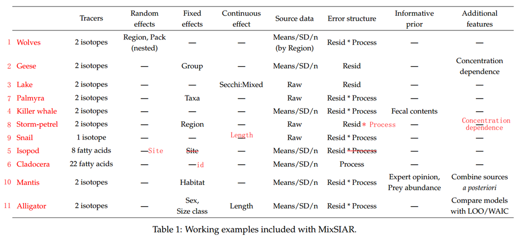

## 官例1-Wolves：随机效应、隶属关系

案例说明（rmarkdown列表前需空一行，列表每一行前无需空格或制表符）

1. 目的：调查狼群的进食来源占比
2. 指纹因子：2个，δ13C和δ15N
3. 汇：
   - 效应因子：有随机效应（区域Region、狼群Pack）、无固定效应、无连续效应
     - Region（3个）：1/2/3
     - Pack（8个）：1/2/3/4/5/6/7/8
   - 效应隶属：狼群隶属于区域
4. 源：
   - 物源（3个）：Deer、Marine Mammals、Salmon
   - 数据类型：means
   - 效应因子：有（Region）
   - 浓度依赖：无
5. 模型：
   - 误差形式：残差乘过程误差（即Stock et al. 2018, PeerJ中的第三种形式）
   - 先验信息：无

### 1. 建模准备

```r
# 加载所需包
library(MixSIAR)
# 案例序号
enum <- 1
# 案例名称
enam <- "wolves"
# 案例路径
edir <- paste0("D:/#R/learn_Bayesian/MixSIARexample", enum, "-", enam)
# 定义文件路径，rmarkdown在代码块中的定义，执行过该代码块后，路径将被重置，因此不建议在代码块中使用
setwd(edir)
```

### 2. 读取捕食者（混合物）指纹数据

此案例中，捕食者为狼群，混合物数据生成函数的参数含义如下：

- `filename = mixname` 字符，文件名字，即csv格式的数据文件全名（路径+文件名）
- `iso_names = c("d13C", "d15N")` 字符串，同位素（指纹因子）的名称，此案例有两个变量，分别为δ13C和δ15N
- `factors = c("Region","Pack")` 字符，混合物数据中的协变量，本案例为区域和狼群（Region和Pack）
- `fac_random = c(TRUE,TRUE)` 布尔，协变量的类型，是否为随机（否则为固定），此处全为随机
- `fac_nested = c(FALSE,TRUE)` 布尔，层级关系，此处含义为Pack隶属于Region
- `cont_effects = NULL` 字符，连续效应的名称，此处为无，为空

本例中，狼群Pack和区域Region有层级隶属关系，Pack隶属于Region，意思是某个狼群完全属于某个区域、狼群中的每个个体也同样隶属于这个区域。汇数据用图示可表示为：

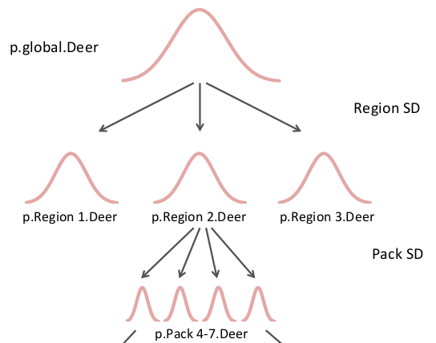

```r
# 读取狼群数据文件名
mixname <- paste0(edir, "/", enam, "_consumer.csv")

# 生成狼群数据
mix <- load_mix_data(filename = mixname,
                     iso_names = c("d13C", "d15N"),
                     factors = c("Region","Pack"),
                     fac_random = c(TRUE,TRUE),
                     fac_nested = c(FALSE,TRUE),
                     cont_effects = NULL)
```

### 3. 读取被捕食者（物源地）指纹数据

本案例中，源为3个区域内，三种动物的同位素平均值、方差数据，物源数据生成函数的参数含义如下：

- `filename = souname` 字符，文件名字，即csv格式的数据文件全名（路径+文件名）
- `source_factors = "Region"` 字符串，物源数据中的协变量，此处为Region
- `conc_dep = FALSE` 布尔，是否有浓度依赖性数据
- `data_type = "means"` 字符，可选`means`或`raw`，均值方差型数据或原始个体数据
- `mix = mix` 列表，`load_mix_data`生成的混合物数据

注意如果使用均值方差数据，原数据中应有一列名为”n”，记录原始样本个数

```r
# 读取物源数据文件名
souname <- paste0(edir, "/", enam, "_sources.csv")

# 生成物源数据
source <- load_source_data(filename = souname,
                           source_factors = "Region",
                           conc_dep = FALSE,
                           data_type = "means",
                           mix = mix)
```

### 4. 读鉴别因子数据

读取营养鉴别因子(TDF)数据，TDF是指消费者在进食某一食物后，机体组织中的生物示踪剂值被修改（富集/耗尽）的量。如果示踪剂是保守的，则将TDF设置为0（例如，必需脂肪酸、脂肪酸分布数据、元素浓度）。

```r
disname <- paste0(edir, "/", enam, "_discrimination.csv")
discr <- load_discr_data(filename = disname, mix = mix)
```

### 5. 数据绘图

对数据进行绘图，以检验：

- 数据是否正确读取
- 混合物是否在来源多边形内部
- 是否有一个或多个来源数据困惑或隐藏

需要注意的是：

- MixSIAR主要通过多边形来检验模型源汇是否有意义，即便无意义，也可以求得结果
- `plot_data`主要根据指纹因子数量，在`plot_data_one_iso`和`plot_data_two_iso`之间选择绘图函数
- 绘图结果文件名后追加的”1_2”表示指纹因子1&2之间的数据图，`plot_data`将对所有指纹因子两两结合绘制这个图

```r
plot_data(filename = "plot_data_isospace",
          plot_save_pdf = F,
          plot_save_png = T,
          mix = mix,
          source = source,
          discr = discr,
          return_obj = T)
```

绘图结果（上述代码在rmarkdown中并不输出图，因此用html展示）：

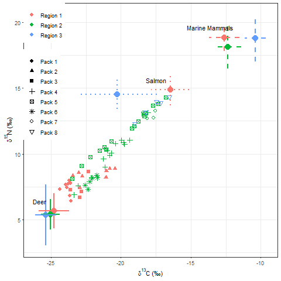

### 6. 计算凸包面积

当且仅当有两个指纹因子时，计算归一化的多边形凸包围表面积

注意：

- 区分SD被添加到源SD(详见?calc_area)
- 如果源数据存在效应因子，则计算第一个效应因子中每项的多边形的面积(如wolf中的每个区域，一共三个)

```r
# 计算凸包面积，由源方差标准化
calc_area(source = source, mix = mix, discr = discr)
#>0.8750158 13.9726701 13.6440547
```

### 7. 绘制先验分布

定义一个先验函数的参数（狄利克雷函数的超参数），然后绘制图形

在这个图中，数据的先验图在左侧，是红色的；无先验/广义先验(alpha = 1)在右侧，是深灰色的。

```r
# 默认参数，即一个不提供先验信息的、广义先验参数，alpha=1
plot_prior(alpha.prior = 1,
           source = source,
           plot_save_pdf = F,
           plot_save_png = T,
           filename = "plot_source_prior")
```

绘图结果（上述代码在rmarkdown中并不输出图，因此用html展示）：

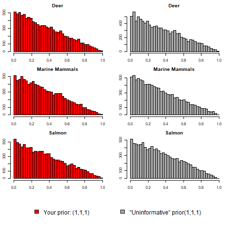

### 8. 构建JAGS模型

JAGS模型有三种误差形式，即

- `resid_err = TRUE, process_err = TRUE` 残差乘过程误差
- `resid_err = TRUE, process_err = FALSE` 残差
- `resid_err = FALSE, process_err = TRUE` 过程误差

注意：如果模型混合物只有1个数据（或每个协变量级别（例如本例中的区域和狼群）只有1个数据），则模型没有关于混合或消费者可变性的信息。

```r
# 生成一个本地txt文档，记录模型信息
model_filename <- paste0(edir, "/MixSIAR_model.txt")

write_JAGS_model(filename = model_filename,
                 resid_err = TRUE,
                 process_err = TRUE,
                 mix = mix,
                 source = source)
```

### 9. 运行JAGS模型

选择运行参数（马尔可夫链蒙特卡罗），通过自定义，或调用几种典型参数

```r
# 可选1，自定义运行参数，DIC是对预期预测误差的估计
run <- list(chainLength = 200000, burn = 150000, thin = 50, chains = 3, calcDIC = TRUE)

# 可选2，选择运行参数模板，先用test测试模型数据是否正确，再用normal寻找可能收敛的解
# 此时run可选test/very short/short/normal/long/very long/extreme等字符形式
  jags.test <- run_model(run="test", mix, source, discr, model_filename)

# 运行normal将耗时半小时
system.time({
  jags.normal <- run_model(run="normal", mix, source, discr, model_filename)
})
```

### 10. 模型结果分析

定义输出项目，再分析模型计算结果

对于函数输入，需要注意：

- 1.output_options list在output_JAGS函数中是按序号读取的，所以list的参数定义要按顺序来
- 2.output_options list中有三个sup_的参数，都要定义为FALSE

对于模型的结果评价，注意以下几点：

- 1.最重要的是判断模型是否收敛，提供三种诊断器：
  - `gelman` 默认，Gelman-Rubin诊断，value < 1.1 可认为模型收敛
  - `geweke` 默认，Geweke诊断，是一个标准化的双侧z检验，比较链的第一部分的平均值与第二部分的平均值。在收敛时，这些平均值应该是相同的，大的绝对z分数表示拒绝。
  - `heidel` Heidelberger-Welch诊断，结果中直接给出哪些是失败的。
- 2.diagnostics.pdf中，有一些诊断图包括
  - Gelman-Rubin plot (same as in diagnostics.txt)
  - • Geweke plot (same as in diagnostics.txt)
  - • Posterior density plots by chain
  - • Traceplots
  - • Running mean plots
  - • Autocorrelation plots
  - • Crosscorrelation plot

```r
# 读取并分析运行结果
# load(paste0(edir, "/model_result.RData"))
output_options <- list(summary_save = FALSE,
                       summary_name = "model_result_1_summary_statistics",
                       sup_post = FALSE,
                       plot_post_save_pdf = FALSE,
                       plot_post_name = "model_result_2_posterior_density",
                       sup_pairs = FALSE,
                       plot_pairs_save_pdf = FALSE,
                       plot_pairs_name = "model_result_3_pairs_plot",
                       sup_xy = FALSE,
                       plot_xy_save_pdf = FALSE,
                       plot_xy_name = "model_result_4_xy_plot",
                       gelman = TRUE,
                       heidel = FALSE,
                       geweke = TRUE,
                       diag_save = TRUE,
                       diag_name = "model_result_5_diagnostics",
                       indiv_effect = FALSE,
                       plot_post_save_png = TRUE,
                       plot_pairs_save_png = TRUE,
                       plot_xy_save_png = TRUE,
                       diag_save_ggmcmc = TRUE)

# 这步，应该有个model_result_5_diagnostics.pdf，但是后几次都没有输出，不知道为什么
output_JAGS(jags.1 = jags.normal,
            mix = mix,
            source = source,
            output_options = output_options)
```

模型结果中的关键指标：

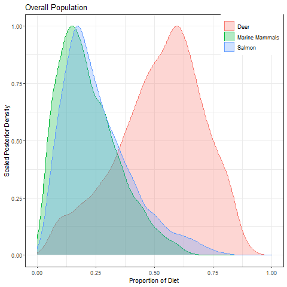

```r
# 读取模型

source$source_names      #模型的源，物源地，按顺序为Deer、Marine Mammals、Salmon
mix$iso_names            #模型的汇，指纹因子(iso)，按顺序为"d13C" "d15N"
mix$factors              #模型的汇，协变量因子(factor)，按顺序为Region、Pack

jags.normal$BUGSoutput$mean$p.global   #模型求得的全局最终平均贡献比（顺序为物源顺序）
jags.normal$BUGSoutput$sd$p.global     #同上，标准差
jags.normal$BUGSoutput$median$p.global #同上，中位数（相加不是1）

jags.normal$BUGSoutput$mean$p.fac1     #因子1内的平均贡献比，即第i行是Region i内source1/2/3的
jags.normal$BUGSoutput$mean$p.fac2     #因子2内的平均贡献比，即第i行是Pack i内source1/2/3的

jags.normal$BUGSoutput$sd$p.fac1       #含义规则同上
jags.normal$BUGSoutput$sd$p.fac2
jags.normal$BUGSoutput$median$p.fac1
jags.normal$BUGSoutput$median$p.fac2

# 如果需要重新绘图，代码可参考output_JAGS，密度数据在jags.1$BUGSoutput$sims.list，全局的例子如下
library(ggplot2)
n.draws <- nrow(jags.1$BUGSoutput$sims.list$p.global)
df <- data.table()
df$sources <- rep(source$source_names, each = n.draws)         #df中x和sources的顺序只能这样，否则会出错
df$x <- matrix(jags.1$BUGSoutput$sims.list$p.global, ncol = 1)
ggplot(df, aes(x=x, fill=sources, colour=sources)) +
  geom_density(alpha=.3, aes(y=..scaled..)) +
  theme_bw() +
  xlab("Proportion of Diet") +
  ylab("Scaled Posterior Density") +
  xlim(0,1) +
  labs(title = my.title) +
  theme(legend.position=c(1,1),
        legend.justification=c(1,1),
        legend.title=element_blank())
```

## 官例2-Geese：固定效应、浓度依赖

案例说明

1. 目的：调查鹅的进食来源占比
2. 指纹因子：2个，δ13C和δ15N
3. 汇：
   - 效应因子：有固定效应（组Group）、无随机效应、无连续效应
     - Group（8个）：1/2/3/4/5/6/7/8
   - 效应隶属：无
4. 源：
   - 物源（4个）：Zostera/Grass/U.lactuca/Enteromorpha
   - 数据类型：means
   - 效应因子：无
   - 浓度依赖：有
5. 模型：
   - 误差形式：仅残差
   - 先验信息：无

```r
# 1.建模准备
# 加载包
library(MixSIAR)
# 案例序号
enum <- 2
# 案例名称
enam <- "geese"
# 案例路径
edir <- paste0("D:/#R/learn_Bayesian/MixSIARexample", enum, "-", enam)
# 定义文件路径
setwd(edir)

# 2.加载混合物数据
mix.filename <- paste0(edir, "/", enam, "_consumer.csv")
mix <- load_mix_data(filename = mix.filename,
                     iso_names = c("d13C","d15N"),
                     factors = "Group",
                     fac_random = FALSE,           #是为随机，否为固定
                     fac_nested = FALSE,           #无嵌套关系
                     cont_effects = NULL)          #无连续效应

# 3.加载物源数据
source.filename <- paste0(edir, "/", enam, "_sources.csv")
source <- load_source_data(filename = source.filename,
                           source_factors = NULL,       #来源并无协变量因子Group
                           conc_dep = TRUE,             #存在浓度依赖变量
                           data_type = "means",         #数据类型为均值型
                           mix = mix)

# 4.加载鉴别因子数据
discr.filename <- paste0(edir, "/", enam, "_discrimination.csv")
discr <- load_discr_data(filename = discr.filename, mix = mix)

# 5.数据绘图
plot_data(filename = "plot_data_isospace",
          plot_save_pdf = F,
          plot_save_png = T,
          mix = mix,
          source = source,
          discr = discr)                    #绘图结果文件名后的"1_2"表示指纹因子1&2之间的数据图

# 6.计算凸包面积
calc_area(source = source, mix = mix, discr = discr)
```

```
#> 20.27097
```

```r
# 7.绘制先验分布
plot_prior(alpha.prior = 1,
           source = source,
           plot_save_pdf = F,
           plot_save_png = T,
           filename = "plot_source_prior")

# 8.建立模型
model_filename <- paste0(edir, "/MixSIAR_model.txt")
write_JAGS_model(filename = model_filename,
                 resid_err = T,     #有残差
                 process_err = F,   #无过程误差
                 mix = mix,
                 source = source)
# 9.运行模型
system.time({
jags.normal <- run_model(run="normal",
                         mix = mix,
                         source = source,
                         discr = discr,
                         model_filename = model_filename,
                         alpha.prior = 1,
                         resid_err = T,
                         process_err = F)
})

# 10.模型结果
# load(paste0(edir, "/model_result.RData"))
output_options <- list(summary_save = TRUE,
                       summary_name = "model_result_1_summary_statistics",
                       sup_post = FALSE,
                       plot_post_save_pdf = FALSE,
                       plot_post_name = "model_result_2_posterior_density",
                       sup_pairs = FALSE,
                       plot_pairs_save_pdf = FALSE,
                       plot_pairs_name = "model_result_3_pairs_plot",
                       sup_xy = FALSE,
                       plot_xy_save_pdf = FALSE,
                       plot_xy_name = "model_result_4_xy_plot",
                       gelman = TRUE,
                       heidel = FALSE,
                       geweke = TRUE,
                       diag_save = TRUE,
                       diag_name = "model_result_5_diagnostics",
                       indiv_effect = FALSE,
                       plot_post_save_png = TRUE,
                       plot_pairs_save_png = TRUE,
                       plot_xy_save_png = TRUE,
                       diag_save_ggmcmc = TRUE)
output_JAGS(jags.normal, mix, source, output_options)

# 指标含义
source$source_names      #模型的源，物源地，"Enteromorpha" "Grass"  "U.lactuca"   "Zostera"
mix$iso_names            #模型的汇，指纹因子，"d13C" "d15N"
mix$factors              #模型的汇，协变量因子，"Group"

jags.normal$BUGSoutput$mean$p.global   #注意，固定效应中，分组是强制的，这个总的已经没有意义了
jags.normal$BUGSoutput$sd$p.global     #同上，
jags.normal$BUGSoutput$median$p.global #同上，

jags.normal$BUGSoutput$mean$p.fac1     #因子1内的平均贡献比，即第i行是Group i内source1/2/3/4的

jags.normal$BUGSoutput$sd$p.fac1       #含义规则同上
jags.normal$BUGSoutput$median$p.fac1
```

## 官例3-Lake：连续效应、原始数据

案例说明

1. 目的：调查21个湖中浮游动物的食物来源
2. 指纹因子：2个，δ13C和δ15N
3. 汇：
   - 效应因子：无随机效应、无固定效应、有连续效应（赛琪深度）
   - 效应隶属：无
4. 源：
   - 物源（3个）：“Subsurface POM” “Surface POM” “Terrestrial Detritus”
   - 数据类型：raw
   - 效应因子：无
   - 浓度依赖：无
5. 模型：
   - 误差形式：仅残差
   - 先验信息：无

```r
# 1.建模准备
# 加载包
library(MixSIAR)
# 案例序号
enum <- 3
# 案例名称
enam <- "lake"
# 案例路径
edir <- paste0("D:/#R/learn_Bayesian/MixSIARexample", enum, "-", enam)
# 定义文件路径
setwd(edir)

# 2.加载混合物数据
mix.filename <- paste0(edir, "/", enam, "_consumer.csv")
mix <- load_mix_data(filename = mix.filename,
                     iso_names = c("d13C","d15N"),
                     factors = NULL,               #无协变量
                     fac_random = NULL,            #无随机和固定
                     fac_nested = NULL,            #无嵌套关系
                     cont_effects = "Secchi.Mixed")#有连续效应，注意用fread读取，会将变量名中的点号变为冒号

# 3.加载物源数据
source.filename <- paste0(edir, "/", enam, "_sources.csv")
source <- load_source_data(filename = source.filename,
                           source_factors = NULL,       #来源并无协变量因子
                           conc_dep = F,                #不存在浓度依赖变量
                           data_type = "raw",           #数据类型为原始型
                           mix = mix)

# 4.加载鉴别因子数据
discr.filename <- paste0(edir, "/", enam, "_discrimination.csv")
discr <- load_discr_data(filename = discr.filename, mix = mix)

# 5.数据绘图
# 绘图结果文件名后的"1_2"表示指纹因子1&2之间的数据图
# 黑白图，因为没有factor了
plot_data(filename = "plot_data_isospace",
          plot_save_pdf = F,
          plot_save_png = T,
          mix = mix,
          source = source,
          discr = discr)

# 6.计算凸包面积
calc_area(source = source, mix = mix, discr = discr)
```

```
#> 3.053018
```

```r
# 7.绘制先验分布
plot_prior(alpha.prior = 1,
           source = source,
           plot_save_pdf = F,
           plot_save_png = T,
           filename = "plot_source_prior")

# 8.建立模型
model_filename <- paste0(edir, "/MixSIAR_model.txt")
write_JAGS_model(filename = model_filename,
                 resid_err = T,     #有残差
                 process_err = F,   #无过程误差
                 mix = mix,
                 source = source)
# 9.运行模型
system.time({
  jags.test <- run_model(run="test",
                           mix = mix,
                           source = source,
                           discr = discr,
                           model_filename = model_filename,
                           alpha.prior = 1,
                           resid_err = T,
                           process_err = F)
})

# 10.模型结果
# load(paste0(edir, "/model_result.RData"))
output_options <- list(summary_save = TRUE,
                       summary_name = "model_result_1_summary_statistics",
                       sup_post = FALSE,
                       plot_post_save_pdf = FALSE,
                       plot_post_name = "model_result_2_posterior_density",
                       sup_pairs = FALSE,
                       plot_pairs_save_pdf = FALSE,
                       plot_pairs_name = "model_result_3_pairs_plot",
                       sup_xy = FALSE,
                       plot_xy_save_pdf = FALSE,
                       plot_xy_name = "model_result_4_xy_plot",
                       gelman = TRUE,
                       heidel = FALSE,
                       geweke = TRUE,
                       diag_save = TRUE,
                       diag_name = "model_result_5_diagnostics",
                       indiv_effect = FALSE,
                       plot_post_save_png = TRUE,
                       plot_pairs_save_png = TRUE,
                       plot_xy_save_png = TRUE,
                       diag_save_ggmcmc = TRUE)
output_JAGS(jags.test, mix, source, output_options)

# 指标含义
source$source_names      #模型的源，物源地，"Subsurface POM" "Surface POM" "Terrestrial Detritus"
mix$iso_names            #模型的汇，指纹因子，"d13C" "d15N"
mix$factors              #模型的汇，协变量因子，NULL

jags.normal$BUGSoutput$mean$p.global   #总体贡献比
jags.normal$BUGSoutput$sd$p.global     #同上，
jags.normal$BUGSoutput$median$p.global #同上，

# 本例中的连续效应，由`plot_continuous_var`函数绘制图像，包括连续变量的自身、最大值、中位数、最小值的密度函数图
```

## 官例4-Killerwhale：有无先验对比

案例说明

1. 目的：调查虎鲸食物来源
2. 指纹因子：2个，δ13C和δ15N
3. 汇：
   - 效应因子：无随机效应、无固定效应、无连续效应
   - 效应隶属：无
4. 源：
   - 物源（5个）：“Chinook” “Chum” “Coho” “Sockeye” “Steelhead”
   - 数据类型：means
   - 效应因子：无
   - 浓度依赖：无
5. 模型：
   - 误差形式：残差乘以过程误差
   - 先验信息：无vs有
6. 本例中模型的先验信息是，14个虎鲸粪便样本，其中5个物源分别对应10/1/0/0/3份，当然可以设定狄利克雷超参数alpha为c(10,1,0,0,3)，但这样的问题是，样本量14含有太大的先验信息，则每个参数空间权重将非常小。因此将每个物源乘以5/14，则最终的kw.alpha与无先验信息的超参数alpha=c(1,1,1,1,1)，具有相同的sum和mean。此外，狄利克雷超参数不能为0，因此可将0赋值为0.01。

```r
# 1.建模准备
# 加载包
library(MixSIAR)
# 案例序号
enum <- 4
# 案例名称
enam <- "killerwhale"
# 案例路径
edir <- paste0("D:/#R/learn_Bayesian/MixSIARexample", enum, "-", enam)
# 定义文件路径
setwd(edir)

# 2.加载混合物数据
mix.filename <- paste0(edir, "/", enam, "_consumer.csv")
mix <- load_mix_data(filename = mix.filename,
                     iso_names = c("d13C","d15N"),
                     factors = NULL,               #无协变量
                     fac_random = NULL,            #无随机和固定
                     fac_nested = NULL,            #无嵌套关系
                     cont_effects = NULL)          #无连续因子

# 3.加载物源数据
source.filename <- paste0(edir, "/", enam, "_sources.csv")
source <- load_source_data(filename = source.filename,
                           source_factors = NULL,       #来源并无协变量因子
                           conc_dep = F,                #不存在浓度依赖变量
                           data_type = "means",         #数据类型为均值型
                           mix = mix)

# 4.加载鉴别因子数据
discr.filename <- paste0(edir, "/", enam, "_discrimination.csv")
discr <- load_discr_data(filename = discr.filename, mix = mix)

# 5.数据绘图
# 绘图结果文件名后的"1_2"表示指纹因子1&2之间的数据图
plot_data(filename = "plot_data_isospace",
          plot_save_pdf = F,
          plot_save_png = T,
          mix = mix,
          source = source,
          discr = discr)

# 6.计算凸包面积
calc_area(source = source, mix = mix, discr = discr)
```

```
#> 12.77484
```

```r
# 7.绘制先验分布
# 7.1 无先验信息
plot_prior(alpha.prior = 1,
           source = source,
           plot_save_pdf = F,
           plot_save_png = T,
           filename = "plot_source_prior1_uninf")
# 7.2 有先验信息
# 来自文献的排泄物样品
kw.alpha <- c(10,1,0,0,3)
# 生成alpha超参数，并用标准化
kw.alpha <- kw.alpha*length(kw.alpha)/sum(kw.alpha)
# 狄利克雷分布的alpha超参数不能为0，可将其设置为0.01
kw.alpha[which(kw.alpha==0)] <- 0.01
# 再次绘制先验分布图
plot_prior(alpha.prior = kw.alpha,
           source = source,
           plot_save_pdf = F,
           plot_save_png = T,
           filename = "plot_source_prior2_inf")

# 8.建立模型（有无先验信息并不影响）
model_filename <- paste0(edir, "/MixSIAR_model.txt")
write_JAGS_model(filename = model_filename,
                 resid_err = T,     #有残差
                 process_err = T,   #有过程误差
                 mix = mix,
                 source = source)
# 9.运行模型
# 9.1无先验信息模型
system.time({
  jags.normal.uninf <- run_model(run="normal",
                                 mix = mix,
                                 source = source,
                                 discr = discr,
                                 model_filename = model_filename,
                                 alpha.prior = 1,
                                 resid_err = T,
                                 process_err = T)
})
# 9.2有先验信息模型
system.time({
  jags.normal.inf <- run_model(run="normal",
                               mix = mix,
                               source = source,
                               discr = discr,
                               model_filename = model_filename,
                               alpha.prior = kw.alpha,
                               resid_err = T,
                               process_err = T)
})



# 10.模型结果
# load(paste0(edir, "/model_result.RData"))
# 10.1无先验信息结果
output_options <- list(summary_save = TRUE,
                       summary_name = "model1_uninf_result_1_summary_statistics",
                       sup_post = FALSE,
                       plot_post_save_pdf = FALSE,
                       plot_post_name = "model1_uninf_result_2_posterior_density",
                       sup_pairs = FALSE,
                       plot_pairs_save_pdf = FALSE,
                       plot_pairs_name = "model1_uninf_result_3_pairs_plot",
                       sup_xy = FALSE,
                       plot_xy_save_pdf = FALSE,
                       plot_xy_name = "model1_uninf_result_4_xy_plot",
                       gelman = TRUE,
                       heidel = FALSE,
                       geweke = TRUE,
                       diag_save = TRUE,
                       diag_name = "model1_uninf_result_5_diagnostics",
                       indiv_effect = FALSE,
                       plot_post_save_png = TRUE,
                       plot_pairs_save_png = TRUE,
                       plot_xy_save_png = TRUE,
                       diag_save_ggmcmc = TRUE)
output_JAGS(jags.normal.uninf, mix, source, output_options)
# 10.2有先验信息结果
output_options <- list(summary_save = TRUE,
                       summary_name = "model2_inf_result_1_summary_statistics",
                       sup_post = FALSE,
                       plot_post_save_pdf = FALSE,
                       plot_post_name = "model2_inf_result_2_posterior_density",
                       sup_pairs = FALSE,
                       plot_pairs_save_pdf = FALSE,
                       plot_pairs_name = "model2_inf_result_3_pairs_plot",
                       sup_xy = FALSE,
                       plot_xy_save_pdf = FALSE,
                       plot_xy_name = "model2_inf_result_4_xy_plot",
                       gelman = TRUE,
                       heidel = FALSE,
                       geweke = TRUE,
                       diag_save = TRUE,
                       diag_name = "model2_inf_result_5_diagnostics",
                       indiv_effect = FALSE,
                       plot_post_save_png = TRUE,
                       plot_pairs_save_png = TRUE,
                       plot_xy_save_png = TRUE,
                       diag_save_ggmcmc = TRUE)
output_JAGS(jags.normal.inf, mix, source, output_options)
```

**结果对比：**

1. 物源先验分布（无vs有）

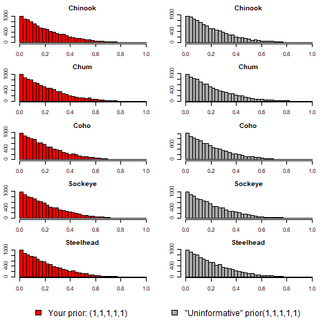

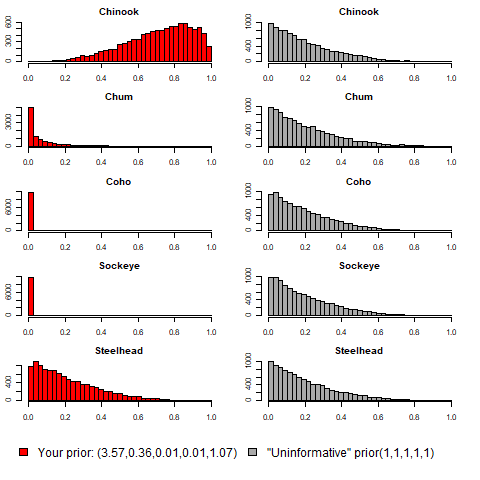

Uninformative vs. Informative

2. 模型结果（无vs有）

```
  无先验信息：
  DIC = -4.393189
                      Mean    SD
  Epsilon.1          1.121 0.812
  Epsilon.2          2.634 2.025
  p.global.Chinook   0.368 0.104
  p.global.Chum      0.108 0.092
  p.global.Coho      0.175 0.131
  p.global.Sockeye   0.071 0.059
  p.global.Steelhead 0.278 0.092
```

```
  有先验信息：
  DIC = -13.66512
                      Mean    SD
  Epsilon.1          0.650 0.433
  Epsilon.2          1.441 0.917
  p.global.Chinook   0.501 0.029
  p.global.Chum      0.073 0.082
  p.global.Coho      0.000 0.000
  p.global.Sockeye   0.000 0.002
  p.global.Steelhead 0.427 0.062
```

3. 贡献比例（无vs有）

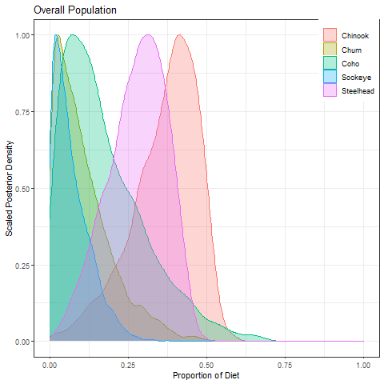

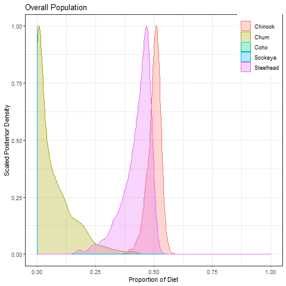

Uninformative vs. Informative

## 官例5-isopod：多指纹、github函数

案例说明

1. 目的：调查等足类动物食物来源（应用多不饱和脂肪酸(PUFA)）
2. 指纹因子：8个，C16.4w3, C18.2w6, C18.3w3, C18.4w3, C20.4w6, C20.5w3, C22.5w3, C22.6w3
3. 汇：
   - 效应因子：有随机效应（site）、无固定效应、无连续效应
     - site（6个）:“CP” “EC” “FHL” “LG” “MN” “RB”
   - 效应隶属：无
4. 源：
   - 物源（3个）：“Brown” “Green” “Red”
   - 数据类型：means
   - 效应因子：无
   - 浓度依赖：无
5. 模型：
   - 误差形式：仅残差
   - 先验信息：无

```r
# 1.建模准备
# 加载包
library(MixSIAR)
# 案例序号
enum <- 5
# 案例名称
enam <- "isopod"
# 案例路径
edir <- paste0("D:/#R/learn_Bayesian/MixSIARexample", enum, "-", enam)
# 定义文件路径
setwd(edir)

# 2.加载混合物数据
mix.filename <- paste0(edir, "/", enam, "_consumer.csv")
mix <- load_mix_data(filename = mix.filename,
                     iso_names =c("c16.4w3","c18.2w6","c18.3w3",
                                  "c18.4w3","c20.4w6","c20.5w3",
                                  "c22.5w3","c22.6w3"),
                     factors = "Site",             #有协变量
                     fac_random = TRUE,            #随机
                     fac_nested = FALSE,           #无嵌套关系
                     cont_effects = NULL)          #无连续因子

# 3.加载物源数据
source.filename <- paste0(edir, "/", enam, "_sources.csv")
source <- load_source_data(filename = source.filename,
                           source_factors = NULL,       #来源并无协变量因子
                           conc_dep = F,                #不存在浓度依赖变量
                           data_type = "means",         #数据类型为均值型
                           mix = mix)

# 4.加载鉴别因子数据
# 数据来自饲养实验，the sources are actually consumers fed exclusively each of the sources. 因此鉴别数据全是0
discr.filename <- paste0(edir, "/", enam, "_discrimination.csv")
discr <- load_discr_data(filename = discr.filename, mix = mix)

# 5.数据绘图
# 绘图结果文件名后的"1_2"表示指纹因子1&2之间的数据图
plot_data(filename = "plot_data_isospace",
          plot_save_pdf = F,
          plot_save_png = T,
          mix = mix,
          source = source,
          discr = discr)

# 6.计算凸包面积
# 算不了，只有两个指纹因子时，才能算，这里都有8个了
calc_area(source = source, mix = mix, discr = discr)

# 7.绘制先验分布
plot_prior(alpha.prior = 1,
           source = source,
           plot_save_pdf = F,
           plot_save_png = T,
           filename = "plot_source_prior")

# 8.建立模型（有无先验信息并不影响）
model_filename <- paste0(edir, "/MixSIAR_model.txt")
write_JAGS_model(filename = model_filename,
                 resid_err = T,     #有残差
                 process_err = F,   #无过程误差
                 mix = mix,
                 source = source)
# 9.运行模型
system.time({
  jags.normal <- run_model(run="normal",
                                 mix = mix,
                                 source = source,
                                 discr = discr,
                                 model_filename = model_filename,
                                 alpha.prior = 1,
                                 resid_err = T,
                                 process_err = F)
})

# 10.模型结果
# load(paste0(edir, "/model_result.RData"))
output_options <- list(summary_save = TRUE,
                       summary_name = "model_result_1_summary_statistics",
                       sup_post = FALSE,
                       plot_post_save_pdf = FALSE,
                       plot_post_name = "model_result_2_posterior_density",
                       sup_pairs = FALSE,
                       plot_pairs_save_pdf = FALSE,
                       plot_pairs_name = "model_result_3_pairs_plot",
                       sup_xy = FALSE,
                       plot_xy_save_pdf = FALSE,
                       plot_xy_name = "model_result_4_xy_plot",
                       gelman = TRUE,
                       heidel = FALSE,
                       geweke = TRUE,
                       diag_save = TRUE,
                       diag_name = "model_result_5_diagnostics",
                       indiv_effect = FALSE,
                       plot_post_save_png = TRUE,
                       plot_pairs_save_png = TRUE,
                       plot_xy_save_png = TRUE,
                       diag_save_ggmcmc = TRUE)
output_JAGS(jags.normal, mix, source, output_options)

# 11.github额外模型输出函数
# 读取额外的5个函数，注意文件夹内需仅有这5个函数的文件
fdir <- "D:/#R/learn_Bayesian/MixSIAR_github_functions"
funs <- list.files(fdir, full.names = T)
base::source(funs[1]) #output_diagnostics
base::source(funs[2]) #output_pairs
base::source(funs[3]) #output_posteriors
base::source(funs[4]) #output_stats
base::source(funs[5]) #output_xy
# 重新定义一个options，以区别上面的输出文件
# 注意多了一句return_obj = TRUE，用于保持对象，以用来分析和绘图
# 结果与与上面一样，就不保存文件了
output_options2 <- output_options <- list(summary_save = TRUE,
                       summary_name = "ops2-model_result_1_summary_statistics",
                       sup_post = FALSE,
                       plot_post_save_pdf = FALSE,
                       plot_post_name = "ops2-model_result_2_posterior_density",
                       sup_pairs = FALSE,
                       plot_pairs_save_pdf = FALSE,
                       plot_pairs_name = "ops2-model_result_3_pairs_plot",
                       sup_xy = FALSE,
                       plot_xy_save_pdf = FALSE,
                       plot_xy_name = "ops2-model_result_4_xy_plot",
                       gelman = TRUE,
                       heidel = FALSE,
                       geweke = TRUE,
                       diag_save = FALSE,
                       diag_name = "ops2-model_result_5_diagnostics",
                       indiv_effect = FALSE,
                       plot_post_save_png = FALSE,
                       plot_pairs_save_png = FALSE,
                       plot_xy_save_png = FALSE,
                       diag_save_ggmcmc = FALSE,
                       return_obj = TRUE)    #注意多了一句return_obj = TRUE
# github函数1，输出模型结果诊断（result_5）
diag <- output_diagnostics(jags.1 = jags.normal, mix = mix, source = source, output_options = output_options2)
# github函数2，输出总体贡献比例分布图（result_3），此图无对象输出，及pair为NULL
pair <- output_pairs(jags.1 = jags.normal, mix = mix, source = source, output_options = output_options2)
# github函数3，输出贡献密度图（result_2，分为总体、按因子、方差等）
post <- output_posteriors(jags.1 = jags.normal, mix = mix, source = source, output_options = output_options2)
graphics.off()  #注意这个函数也会打开图像设备，并且不会自己关
post$global+    #本质上是ggplot2对象，可以进行修改，也可以读取其中的数据，自己画图
  ggplot2::scale_fill_manual(values=c("#999999", "#E69F00", "#56B4E9")) +
  ggplot2::scale_color_manual(values=c("#999999", "#E69F00", "#56B4E9"))
post$global+    #本质上是ggplot2对象，可以进行修改，也可以读取其中的数据，自己画图
ggplot2::theme(legend.position="right")   #图例经常遮挡图像，这个位置设置可以很好的修改
# github函数4，输出模型的统计结果（result_1)
stat <- output_stats(jags.1 = jags.normal, mix = mix, source = source, output_options = output_options2)
# github函数5，各来源的贡献、标准差（如果有）的线形图（result_4)，此图无对象输出，及pair为NULL
xyli <- output_xy(jags.1 = jags.normal, mix = mix, source = source, output_options = output_options2)
graphics.off()  #注意这个函数也会打开图像设备，并且不会自己关
```

## 官例6-cladocera：多指纹、过程误差

案例说明

1. 目的：调查水蚤食物来源（此案例不同之处在于，由于没有明确的协变量结构，因此将对每个混合物个体进行拟合，方法是定义一个id列，并将其视为固定效应，为此，误差传递形式为“仅过程”）
2. 指纹因子：22个，(C14.0, C16.0, C16.1w9, C16.1w7, C16.2w4, C16.3w3, C16.4w3, C17.0, C18.0, C18.1w9, C18.1w7, C18.2w6, C18.3w6, C18.3w3, C18.4w3, C18.5w3, C20.0, C22.0, C20.4w6, C20.5w3, C22.6w3, CBrFA)
3. 汇：
   - 效应因子：无随机效应、有固定效应（id）、无连续效应
     - id（14个）：1~14
   - 效应隶属：无
4. 源：
   - 物源（7个）：“Bacill” “Bacteria” “Chl+Cya” “Chryso” “Crypto” “Dino” “t-POM”
   - 数据类型：means
   - 效应因子：无
   - 浓度依赖：无
5. 模型：
   - 误差形式：仅过程
   - 先验信息：无

```r
# 1.建模准备
# 加载包
library(MixSIAR)
# 案例序号
enum <- 6
# 案例名称
enam <- "cladocera"
# 案例路径
edir <- paste0("D:/#R/learn_Bayesian/MixSIARexample", enum, "-", enam)
# 定义文件路径
setwd(edir)

# 2.加载混合物数据
mix.filename <- paste0(edir, "/", enam, "_consumer.csv")
mix <- load_mix_data(filename = mix.filename,
                     iso_names =c("c14.0","c16.0","c16.1w9","c16.1w7","c16.2w4",
                                 "c16.3w3","c16.4w3","c17.0","c18.0","c18.1w9",
                                 "c18.1w7","c18.2w6","c18.3w6","c18.3w3","c18.4w3",
                                 "c18.5w3","c20.0","c22.0","c20.4w6","c20.5w3",
                                 "c22.6w3","BrFA"),
                     factors = "id",               #有协变量
                     fac_random = FALSE,           #固定
                     fac_nested = FALSE,           #无嵌套关系，
                     cont_effects = NULL)          #无连续因子

# 3.加载物源数据
source.filename <- paste0(edir, "/", enam, "_sources.csv")
source <- load_source_data(filename = source.filename,
                           source_factors = NULL,       #来源并无协变量因子
                           conc_dep = F,                #不存在浓度依赖变量
                           data_type = "means",         #数据类型为均值型
                           mix = mix)

# 4.加载鉴别因子数据
discr.filename <- paste0(edir, "/", enam, "_discrimination.csv")
discr <- load_discr_data(filename = discr.filename, mix = mix)

# 5.数据绘图
# 绘图结果文件名后的"1_2"表示指纹因子1&2之间的数据图
# 图太多了不画了，考虑non-metric multidimensional scaling (NMDS) plots吧
# plot_data(filename = "plot_data_isospace",
#           plot_save_pdf = F,
#           plot_save_png = T,
#           mix = mix,
#           source = source,
#           discr = discr)

# 6.计算凸包面积
# 算不了，只有两个指纹因子时，才能算，这里都有22个了
# calc_area(source = source, mix = mix, discr = discr)

# 7.绘制先验分布
plot_prior(alpha.prior = 1,
           source = source,
           plot_save_pdf = F,
           plot_save_png = T,
           filename = "plot_source_prior")

# 8.建立模型（有无先验信息并不影响）
model_filename <- paste0(edir, "/MixSIAR_model.txt")
write_JAGS_model(filename = model_filename,
                 resid_err = F,     #无残差
                 process_err = T,   #有过程误差
                 mix = mix,
                 source = source)
# 9.运行模型
system.time({
  jags.normal <- run_model(run="normal",
                                 mix = mix,
                                 source = source,
                                 discr = discr,
                                 model_filename = model_filename,
                                 alpha.prior = 1,
                                 resid_err = F,
                                 process_err = T)
})

# 10.模型结果
# load(paste0(edir, "/model_result.RData"))
output_options <- list(summary_save = TRUE,
                       summary_name = "model_result_1_summary_statistics",
                       sup_post = FALSE,
                       plot_post_save_pdf = FALSE,
                       plot_post_name = "model_result_2_posterior_density",
                       sup_pairs = FALSE,
                       plot_pairs_save_pdf = FALSE,
                       plot_pairs_name = "model_result_3_pairs_plot",
                       sup_xy = FALSE,
                       plot_xy_save_pdf = FALSE,
                       plot_xy_name = "model_result_4_xy_plot",
                       gelman = TRUE,
                       heidel = FALSE,
                       geweke = TRUE,
                       diag_save = TRUE,
                       diag_name = "model_result_5_diagnostics",
                       indiv_effect = FALSE,
                       plot_post_save_png = TRUE,
                       plot_pairs_save_png = TRUE,
                       plot_xy_save_png = TRUE,
                       diag_save_ggmcmc = TRUE)
output_JAGS(jags.normal, mix, source, output_options)
```

## 官例7-palmyra：更为明确的固定效应

案例说明

1. 目的：黑鳍鲨/灰礁鲨/红鲷鱼三种大型珊瑚礁捕食者的食物来源
2. 指纹因子：2个，d13C,d15N
3. 汇：
   - 效应因子：无随机效应、有固定效应（taxa）、无连续效应
     - taxa（3个）：“Blacktip shark” “Grey reef shark” “Red Snapper”
   - 效应隶属：无
4. 源：
   - 物源（3个）：“Lagoon” “Pelagic” “Reef”
   - 数据类型：raw
   - 效应因子：无
   - 浓度依赖：无
5. 模型：
   - 误差形式：残差乘以过程误差
   - 先验信息：无

```r
# 1.建模准备
# 加载包
library(MixSIAR)
# 案例序号
enum <- 7
# 案例名称
enam <- "palmyra"
# 案例路径
edir <- paste0("D:/#R/learn_Bayesian/MixSIARexample", enum, "-", enam)
# 定义文件路径
setwd(edir)

# 2.加载混合物数据
mix.filename <- paste0(edir, "/", enam, "_consumer.csv")
mix <- load_mix_data(filename = mix.filename,
                     iso_names =c("d13C","d15N"),
                     factors = "Taxa",             #有协变量
                     fac_random = FALSE,           #固定
                     fac_nested = FALSE,           #无嵌套关系，
                     cont_effects = NULL)          #无连续因子

# 3.加载物源数据
source.filename <- paste0(edir, "/", enam, "_sources.csv")
source <- load_source_data(filename = source.filename,
                           source_factors = NULL,       #来源并无协变量因子
                           conc_dep = F,                #不存在浓度依赖变量
                           data_type = "raw",           #数据类型为原始型
                           mix = mix)

# 4.加载鉴别因子数据
discr.filename <- paste0(edir, "/", enam, "_discrimination.csv")
discr <- load_discr_data(filename = discr.filename, mix = mix)

# 5.数据绘图
# 绘图结果文件名后的"1_2"表示指纹因子1&2之间的数据图
plot_data(filename = "plot_data_isospace",
          plot_save_pdf = F,
          plot_save_png = T,
          mix = mix,
          source = source,
          discr = discr)

# 6.计算凸包面积
calc_area(source = source, mix = mix, discr = discr)
#>1.186978

# 7.绘制先验分布
plot_prior(alpha.prior = 1,
           source = source,
           plot_save_pdf = F,
           plot_save_png = T,
           filename = "plot_source_prior")

# 8.建立模型（有无先验信息并不影响）
model_filename <- paste0(edir, "/MixSIAR_model.txt")
write_JAGS_model(filename = model_filename,
                 resid_err = T,     #有残差
                 process_err = T,   #有过程误差
                 mix = mix,
                 source = source)
# 9.运行模型
system.time({
  jags.test <- run_model(run="test",
                                 mix = mix,
                                 source = source,
                                 discr = discr,
                                 model_filename = model_filename,
                                 alpha.prior = 1,
                                 resid_err = T,
                                 process_err = T)
})

# 10.模型结果
# load(paste0(edir, "/model_result.RData"))
output_options <- list(summary_save = TRUE,
                       summary_name = "model_result_1_summary_statistics",
                       sup_post = FALSE,
                       plot_post_save_pdf = FALSE,
                       plot_post_name = "model_result_2_posterior_density",
                       sup_pairs = FALSE,
                       plot_pairs_save_pdf = FALSE,
                       plot_pairs_name = "model_result_3_pairs_plot",
                       sup_xy = FALSE,
                       plot_xy_save_pdf = FALSE,
                       plot_xy_name = "model_result_4_xy_plot",
                       gelman = TRUE,
                       heidel = FALSE,
                       geweke = TRUE,
                       diag_save = TRUE,
                       diag_name = "model_result_5_diagnostics",
                       indiv_effect = FALSE,
                       plot_post_save_png = TRUE,
                       plot_pairs_save_png = TRUE,
                       plot_xy_save_png = TRUE,
                       diag_save_ggmcmc = TRUE)
output_JAGS(jags.test, mix, source, output_options)
```

## 官例8-stormpetrel：非捕食案例

案例说明

1. 目的：反应燕子的迁徙过程（三个地点既为源地又为汇地），其中汇是幼年燕，源是成年燕，假设是来自同一区域的燕子具有相似的同位素特征，此外假设幼年燕和成年燕的辨别因子相同，即则辨别因子全为0。test的结果表明加拿大的燕子最野，苏格兰的燕子最宅。
2. 指纹因子：2个，d13C,d15N
3. 汇：
   - 效应因子：无随机效应、有固定效应（Region）、无连续效应
     - Region（3个）：“Canada” “Iceland” “Scotland”
   - 效应隶属：无
4. 源：
   - 物源（3个）： “Canada” “Iceland” “Scotland”
   - 数据类型：raw
   - 效应因子：无
   - 浓度依赖：有
5. 模型：
   - 误差形式：残差乘以过程误差
   - 先验信息：无

```r
# 1.建模准备
# 加载包
library(MixSIAR)
# 案例序号
enum <- 8
# 案例名称
enam <- "stormpetrel"
# 案例路径
edir <- paste0("D:/#R/learn_Bayesian/MixSIARexample", enum, "-", enam)
# 定义文件路径
setwd(edir)

# 2.加载混合物数据
mix.filename <- paste0(edir, "/", enam, "_consumer.csv")
mix <- load_mix_data(filename = mix.filename,
                     iso_names =c("d13C","d15N"),
                     factors = "Region",           #有协变量
                     fac_random = FALSE,           #固定
                     fac_nested = FALSE,           #无嵌套关系，
                     cont_effects = NULL)          #无连续因子

# 3.加载物源数据
source.filename <- paste0(edir, "/", enam, "_sources.csv")
source <- load_source_data(filename = source.filename,
                           source_factors = NULL,       #来源并无协变量因子
                           conc_dep = T,                #有浓度依赖变量
                           data_type = "raw",           #数据类型为原始型
                           mix = mix)

# 4.加载鉴别因子数据
discr.filename <- paste0(edir, "/", enam, "_discrimination.csv")
discr <- load_discr_data(filename = discr.filename, mix = mix)

# 5.数据绘图
# 绘图结果文件名后的"1_2"表示指纹因子1&2之间的数据图
plot_data(filename = "plot_data_isospace",
          plot_save_pdf = F,
          plot_save_png = T,
          mix = mix,
          source = source,
          discr = discr)

# 6.计算凸包面积
calc_area(source = source, mix = mix, discr = discr)
#>13.51959

# 7.绘制先验分布
plot_prior(alpha.prior = 1,
           source = source,
           plot_save_pdf = F,
           plot_save_png = T,
           filename = "plot_source_prior")

# 8.建立模型（有无先验信息并不影响）
model_filename <- paste0(edir, "/MixSIAR_model.txt")
write_JAGS_model(filename = model_filename,
                 resid_err = T,     #有残差
                 process_err = T,   #有过程误差
                 mix = mix,
                 source = source)
# 9.运行模型
system.time({
  jags.test <- run_model(run="test",
                                 mix = mix,
                                 source = source,
                                 discr = discr,
                                 model_filename = model_filename,
                                 alpha.prior = 1,
                                 resid_err = T,
                                 process_err = T)
})

# 10.模型结果
# load(paste0(edir, "/model_result.RData"))
output_options <- list(summary_save = TRUE,
                       summary_name = "model_result_1_summary_statistics",
                       sup_post = FALSE,
                       plot_post_save_pdf = FALSE,
                       plot_post_name = "model_result_2_posterior_density",
                       sup_pairs = FALSE,
                       plot_pairs_save_pdf = FALSE,
                       plot_pairs_name = "model_result_3_pairs_plot",
                       sup_xy = FALSE,
                       plot_xy_save_pdf = FALSE,
                       plot_xy_name = "model_result_4_xy_plot",
                       gelman = TRUE,
                       heidel = FALSE,
                       geweke = TRUE,
                       diag_save = TRUE,
                       diag_name = "model_result_5_diagnostics",
                       indiv_effect = FALSE,
                       plot_post_save_png = TRUE,
                       plot_pairs_save_png = TRUE,
                       plot_xy_save_png = TRUE,
                       diag_save_ggmcmc = TRUE)
output_JAGS(jags.test, mix, source, output_options)
```

## 官例9-snail：单指纹判别两个物源

案例说明

1. 目的：研究蜗牛在PAM(crassulacean acid metabolism pathway景天酸代谢途径)和C3(3-磷酸甘油酸)植物之间的偏好。
2. 指纹因子：1个，d13C
3. 汇：
   - 效应因子：无随机效应、无固定效应、有连续效应（Length）
   - 效应隶属：无
4. 源：
   - 物源（2个）： “C3” “CAM”
   - 数据类型：raw
   - 效应因子：无
   - 浓度依赖：无
5. 模型：
   - 误差形式：残差乘以过程误差
   - 先验信息：无

```r
# 1.建模准备
# 加载包
library(MixSIAR)
# 案例序号
enum <- 9
# 案例名称
enam <- "snail"
# 案例路径
edir <- paste0("D:/#R/learn_Bayesian/MixSIARexample", enum, "-", enam)
# 定义文件路径
setwd(edir)

# 2.加载混合物数据
mix.filename <- paste0(edir, "/", enam, "_consumer.csv")
mix <- load_mix_data(filename = mix.filename,
                     iso_names =c("d13C"),
                     factors = NULL,               #无协变量
                     fac_random = NULL,            #无固定随机
                     fac_nested = FALSE,           #无嵌套关系，
                     cont_effects = "Length")      #有连续因子

# 3.加载物源数据
source.filename <- paste0(edir, "/", enam, "_sources.csv")
source <- load_source_data(filename = source.filename,
                           source_factors = NULL,       #无协变量因子
                           conc_dep = F,                #无浓度依赖变量
                           data_type = "raw",           #数据类型为均值型
                           mix = mix)

# 4.加载鉴别因子数据
discr.filename <- paste0(edir, "/", enam, "_discrimination.csv")
discr <- load_discr_data(filename = discr.filename, mix = mix)

# 5.数据绘图
plot_data(filename = "plot_data_isospace",
          plot_save_pdf = F,
          plot_save_png = T,
          mix = mix,
          source = source,
          discr = discr)

# 6.计算凸包面积（只有一个指纹因子，算不了）
# calc_area(source = source, mix = mix, discr = discr)

# 7.绘制先验分布
plot_prior(alpha.prior = 1,
           source = source,
           plot_save_pdf = F,
           plot_save_png = T,
           filename = "plot_source_prior")

# 8.建立模型（有无先验信息并不影响）
model_filename <- paste0(edir, "/MixSIAR_model.txt")
write_JAGS_model(filename = model_filename,
                 resid_err = T,     #有残差
                 process_err = T,   #有过程误差
                 mix = mix,
                 source = source)
# 9.运行模型
system.time({
  jags.test <- run_model(run="test",
                                 mix = mix,
                                 source = source,
                                 discr = discr,
                                 model_filename = model_filename,
                                 alpha.prior = 1,
                                 resid_err = T,
                                 process_err = T)
})

# 10.模型结果
load(paste0(edir, "/model_result.RData"))
#10.1无先验信息结果
output_options <- list(summary_save = TRUE,
                       summary_name = "model_result_1_summary_statistics",
                       sup_post = FALSE,
                       plot_post_save_pdf = FALSE,
                       plot_post_name = "model_result_2_posterior_density",
                       sup_pairs = FALSE,
                       plot_pairs_save_pdf = FALSE,
                       plot_pairs_name = "model_result_3_pairs_plot",
                       sup_xy = FALSE,
                       plot_xy_save_pdf = FALSE,
                       plot_xy_name = "model_result_4_xy_plot",
                       gelman = TRUE,
                       heidel = FALSE,
                       geweke = TRUE,
                       diag_save = TRUE,
                       diag_name = "model_result_5_diagnostics",
                       indiv_effect = FALSE,
                       plot_post_save_png = TRUE,
                       plot_pairs_save_png = TRUE,
                       plot_xy_save_png = TRUE,
                       diag_save_ggmcmc = TRUE)
output_JAGS(jags.test, mix, source, output_options)
```

## 官例10-mantis：先验信息、合并物源

案例说明

```r
# 1.建模准备
# 加载包
library(MixSIAR)
# 案例序号
enum <- 10
# 案例名称
enam <- "mantis"
# 案例路径
edir <- paste0("D:/#R/learn_Bayesian/MixSIARexample", enum, "-", enam)
# 定义文件路径
setwd(edir)

# 2.加载混合物数据
mix.filename <- paste0(edir, "/", enam, "_consumer.csv")
mix <- load_mix_data(filename = mix.filename,
                     iso_names =c("d13C", "d15N"),
                     factors = "Habitat",          #有协变量
                     fac_random = FALSE,           #固定效应
                     fac_nested = FALSE,           #无嵌套关系，
                     cont_effects = NULL)          #无连续因子

# 3.加载物源数据
source.filename <- paste0(edir, "/", enam, "_sources.csv")
source <- load_source_data(filename = source.filename,
                           source_factors = "Habitat",  #有协变量
                           conc_dep = T,                #有浓度依赖变量
                           data_type = "means",         #数据类型为均值型
                           mix = mix)

# 4.加载鉴别因子数据
discr.filename <- paste0(edir, "/", enam, "_discrimination.csv")
discr <- load_discr_data(filename = discr.filename, mix = mix)

# 5.数据绘图
plot_data(filename = "plot_data_isospace",
          plot_save_pdf = F,
          plot_save_png = T,
          mix = mix,
          source = source,
          discr = discr)

# 6.计算凸包面积
calc_area(source = source, mix = mix, discr = discr)
#>7.056381 18.789736

# 7.绘制先验分布
# 7.1绘制默认的无先验或一致先验(alpha = 1)
alpha.unif <- rep(1, source$n.sources)
plot_prior(alpha.prior = alpha.unif,
           source = source,
           plot_save_pdf = F,
           plot_save_png = T,
           filename = "plot_source_prior1_unif")
# 7.2专家知识表明，螳螂虾捕食硬壳动物的数量是软体动物的4倍，据此更新先验信息
alpha.spec <- c(1,1,4,4,1,4)
alpha.spec <- alpha.spec*length(alpha.spec)/sum(alpha.spec)
plot_prior(alpha.prior = alpha.spec,
           source = source,
           plot_save_pdf = F,
           plot_save_png = T,
           filename = "plot_source_prior2_spec")
# 7.3两个栖息地，物源物种的丰度数据可用来建立先验信息，但是由于是两个栖息地的先验信息，因此只能分别建模求解
# 栖息地seagrass，丰度先验信息
alpha.grass <- c(0.35,1.61,0.43,(51.65+0.26),5.18,40.5)*6/100
plot_prior(alpha.prior = alpha.grass,
           source = source,
           plot_save_pdf = F,
           plot_save_png = T,
           filename = "plot_source_prior3_1grass")
# 栖息地Coral，丰度先验信息
alpha.coral <- c((14.31+24.74),0.01,15.48,(13.81+4.71),8.44,18.51)*6/100
plot_prior(alpha.prior = alpha.coral,
           source = source,
           plot_save_pdf = F,
           plot_save_png = T,
           filename = "plot_source_prior3_2coral")

# 8.建立模型（有无先验信息并不影响）
model_filename <- paste0(edir, "/MixSIAR_model.txt")
write_JAGS_model(filename = model_filename,
                 resid_err = T,     #有残差
                 process_err = T,   #有过程误差
                 mix = mix,
                 source = source)
# 9.运行模型
system.time({
  jags.normal <- run_model(run="normal",
                                 mix = mix,
                                 source = source,
                                 discr = discr,
                                 model_filename = model_filename,
                                 alpha.prior = alpha.spec,
                                 resid_err = T,
                                 process_err = T)
})

# 10.模型结果(专家验信息结果)
load(paste0(edir, "/model_result.RData"))
output_options <- list(summary_save = TRUE,
                       summary_name = "model1_spec_result_1_summary_statistics",
                       sup_post = FALSE,
                       plot_post_save_pdf = FALSE,
                       plot_post_name = "model1_spec_result_2_posterior_density",
                       sup_pairs = FALSE,
                       plot_pairs_save_pdf = FALSE,
                       plot_pairs_name = "model1_spec_result_3_pairs_plot",
                       sup_xy = FALSE,
                       plot_xy_save_pdf = FALSE,
                       plot_xy_name = "model1_spec_result_4_xy_plot",
                       gelman = TRUE,
                       heidel = FALSE,
                       geweke = TRUE,
                       diag_save = TRUE,
                       diag_name = "model1_spec_result_5_diagnostics",
                       indiv_effect = FALSE,
                       plot_post_save_png = TRUE,
                       plot_pairs_save_png = TRUE,
                       plot_xy_save_png = TRUE,
                       diag_save_ggmcmc = TRUE)
output_JAGS(jags.normal, mix, source, output_options)

# 11.物源重组
# 为了回答螳螂虾是否更偏向于捕食硬壳动物，将原6个物源进行融合，同时为了对比，将原物源也做同样转换
# 6物源融合为2物源
combined <- combine_sources(jags.1 = jags.normal,
                            mix = mix,
                            source = source,
                            alpha.prior = alpha.spec,
                            groups=list(hard=c("clam","crab","snail"),
                                        soft=c("alphworm","brittlestar","fish")))
# 6物源融合为6物源
original <- combine_sources(jags.1 = jags.normal,
                            mix = mix,
                            source = source,
                            alpha.prior = alpha.spec,
                            groups=list(alphworm="alphworm",
                                        brittlestar="brittlestar",
                                        clam="clam",
                                        crab="crab",
                                        fish="fish",
                                        snail="snail"))
# 输出模型总结
summary_stat(combined = combined,
             savetxt = T,
             filename = "combined_summary_statistics_sources6to2")
summary_stat(combined = original,
             savetxt = T,
             filename = "combined_summary_statistics_sources6to6")

# 12.绘制置信区间图（由于bayesplot包的mcmc_intervals绘图功能不能用了，所以下面的绘图功能全部失效！）
# Original 6-source model
plot_intervals(original,toplot="fac1")
# Aggregated posteriors, 6 sources combined into 2 groups
plot_intervals(combined,toplot="fac1")
# level 1 = Seagrass
plot_intervals(combined,toplot="fac1",levels=1)
# level 2 = Coral
plot_intervals(combined,toplot="fac1",levels=2)
```

## 官例11-Alligator：变量优势、模型对比

案例说明

1. 目的：短吻鳄的主要食物来源是淡水or海水？对海水来源的饮食占比，与短吻鳄的长度、性别、个体之间的差异？个体的饮食相对于群体水平的变化有多大?为了回答这些问题，采用传统的SIAR模型需要将数据分为8个子集（2个性别、4个尺寸）分别建立8个独立的模型。而使用MixSIAR只需要对不同模型设置不同的效应和协变量即可，模型的对比则通过基于信息准则（LOO/WAIC）的支持度进行评价。
2. 指纹因子：2个，“d13C”,“d15N”
3. 汇：
   - 效应因子：8种组合
   - 效应隶属：无
4. 源：
   - 物源（2个）： “Marine” “Freshwater”
   - 数据类型：means
   - 效应因子：无
   - 浓度依赖：无
5. 模型：
   - 8种类型（：
     - 1: NULL
     - 2: habitat (3 habitats: fresh, intermediate, marine)
     - 3: sex (male, female)
     - 4: sclass (4 size classes: small juv, large juv, sub-adult, adult)
     - 5: length (continuous effect)
     - 6: sex + sclass (as in Nifong 2015, both as fixed effects)
     - 7: sex + length (intercept by sex, same slope)
     - 8: sex_sclass (create new factor = sex * sclass)
   - 误差形式：残差乘以过程误差
   - 先验信息：无

```r
# 1.建模准备
# 加载包
library(MixSIAR)
# 案例序号
enum <- 11
# 案例名称
enam <- "alligator"
# 案例路径
edir <- paste0("D:/#R/learn_Bayesian/MixSIARexample", enum, "-", enam)
# 定义文件路径
setwd(edir)

# 2.加载混合物数据，分8个模型
mod.n <- 8
mix.filename <- paste0(edir, "/", enam, "_consumer.csv")
mix <- vector("list", mod.n)
mix[[1]] <- load_mix_data(filename = mix.filename,
                          iso_names =c("d13C","d15N"),
                          factors = NULL,
                          fac_random = NULL,
                          fac_nested = NULL,
                          cont_effects = NULL)
mix[[2]] <- load_mix_data(filename = mix.filename,
                          iso_names =c("d13C","d15N"),
                          factors = "habitat",
                          fac_random = F,
                          fac_nested = F,
                          cont_effects = NULL)
mix[[3]] <- load_mix_data(filename = mix.filename,
                          iso_names =c("d13C","d15N"),
                          factors = "sex",
                          fac_random = F,
                          fac_nested = F,
                          cont_effects = NULL)
mix[[4]] <- load_mix_data(filename = mix.filename,
                          iso_names =c("d13C","d15N"),
                          factors = "sclass",
                          fac_random = F,
                          fac_nested = F,
                          cont_effects = NULL)
mix[[5]] <- load_mix_data(filename = mix.filename,
                          iso_names =c("d13C","d15N"),
                          factors = NULL,
                          fac_random = NULL,
                          fac_nested = NULL,
                          cont_effects = "Length")
mix[[6]] <- load_mix_data(filename = mix.filename,
                          iso_names = c("d13C","d15N"),
                          factors = c("sex","sclass"),
                          fac_random = c(FALSE,FALSE),
                          fac_nested = c(FALSE,FALSE),
                          cont_effects = NULL)
mix[[7]] <- load_mix_data(filename = mix.filename,
                          iso_names = c("d13C","d15N"),
                          factors = "sex",
                          fac_random = FALSE,
                          fac_nested = FALSE,
                          cont_effects = "Length")
mix[[8]] <- load_mix_data(filename = mix.filename,
                          iso_names = c("d13C","d15N"),
                          factors = "sex_sclass",
                          fac_random = FALSE,
                          fac_nested = FALSE,
                          cont_effects = NULL)

# 3.构建并运行模型
source <- vector("list", mod.n)
discr <- vector("list", mod.n)
jags.mod <- vector("list", mod.n)
area.val <- vector("list", mod.n)
source.filename <- paste0(edir, "/", enam, "_sources.csv")
discr.filename <- paste0(edir, "/", enam, "_discrimination.csv")
startTime <- Sys.time()
for(mod in 1:mod.n){
  # 新建文件夹以存储文件
  mainDir <- getwd()
  subDir <- paste0("model_", mod)
  dir.create(file.path(mainDir, subDir), showWarnings = FALSE)
  setwd(file.path(mainDir, subDir))
  tDir <- getwd()
  # 读取源
  source[[mod]] <- load_source_data(filename = source.filename,
                           source_factors = NULL,       #无协变量因子
                           conc_dep = F,                #无浓度依赖变量
                           data_type = "means",         #数据类型为均值型
                           mix = mix[[mod]])
  # 读TEF
  discr[[mod]] <- load_discr_data(filename = discr.filename, mix = mix[[mod]])
  # 绘制数据图
  plot_data(filename = paste0("model_", mod, "-plot_data_isospace"),
          plot_save_pdf = F,
          plot_save_png = T,
          mix = mix[[mod]],
          source = source[[mod]],
          discr = discr[[mod]])
  # 计算凸包面积
  area.val[[mod]] <- calc_area(source = source[[mod]], mix = mix[[mod]], discr = discr[[mod]])
  # 绘制先验分布（因为所有模型源都一样，所以没必要都画，这里只在运行前画了一个）
  # plot_prior(alpha.prior = 1,
  #            source = source[[mod]],
  #            plot_save_pdf = F,
  #            plot_save_png = T,
  #            filename = "plot_source_prior")
  # 建立模型（有无先验信息并不影响）
  model_filename <- paste0(tDir, "/model_",mod,"-MixSIAR_model.txt")
  write_JAGS_model(filename = model_filename,
                   resid_err = T,     #有残差
                   process_err = T,   #有过程误差
                   mix = mix[[mod]],
                   source = source[[mod]])
  # 运行模型
  jags.mod[[mod]] <- run_model(run = "short",
                               mix = mix[[mod]],
                               source = source[[mod]],
                               discr = discr[[mod]],
                               model_filename = model_filename,
                               alpha.prior = 1,
                               resid_err = T,
                               process_err = T)
  # 结果分析
  output_options <- list(summary_save = TRUE,
                         summary_name = paste0("model_",mod,"-model_result_1_summary_statistics"),
                         sup_post = FALSE,
                         plot_post_save_pdf = FALSE,
                         plot_post_name = paste0("model_",mod,"-model_result_2_posterior_density"),
                         sup_pairs = FALSE,
                         plot_pairs_save_pdf = FALSE,
                         plot_pairs_name = paste0("model_",mod,"-model_result_3_pairs_plot"),
                         sup_xy = FALSE,
                         plot_xy_save_pdf = FALSE,
                         plot_xy_name = paste0("model_",mod,"-model_result_4_xy_plot"),
                         gelman = TRUE,
                         heidel = FALSE,
                         geweke = TRUE,
                         diag_save = TRUE,
                         diag_name = paste0("model_",mod,"-model_result_5_diagnostics"),
                         indiv_effect = FALSE,
                         plot_post_save_png = TRUE,
                         plot_pairs_save_png = TRUE,
                         plot_xy_save_png = TRUE,
                         diag_save_ggmcmc = TRUE)
  output_JAGS(jags.1 = jags.mod[[mod]],
              mix = mix[[mod]],
              source = source[[mod]],
              output_options = output_options)
  graphics.off()
  setwd(mainDir)
}
endTime <- Sys.time()
endTime - startTime    #耗时3.872049 hours

# 4.模型对比
# MixSIAR使用LOO包，计算LOO (leave-one-out cross-validation)或WAIC (widely applicable information criterion)
# LOO和WAIC是利用参数值的后验模拟评估的对数似然，从拟合贝叶斯模型中估计逐点样本外预测精度的方法
# 简单来说，LOO和WAIC比AIC或DIC要好，LOO比WAIC更鲁棒，loo包计算两个模型的LOO差(dLOOic)，MixSIAR使用赤池权重计算相对支持度。
# 为模型添加名字：
names(jags.mod) <- c("Null",
                     "Habitat",
                     "Sex",
                     "Size class",
                     "Length",
                     "Sex + Size class",
                     "Sex + Length",
                     "Sex : Length")
# 生成对比表
# 这个结果解释为，模型“Length”，赤池权重为0.86，即这个是最优模型的可能性为86%（根据观察到的数据，在考虑的模型之外的新数据的预期预测性能）
comparison.table <- compare_models(jags.mod)
```